# Block 3: Homework Solutions

Henrique Sposito and Livio Silva-Muller

October 2022

## Question 1

Create a bar plot displaying the top 10 overall donors and their total donations to all international organizations. Please color the donors by their type (e.g. public or private).

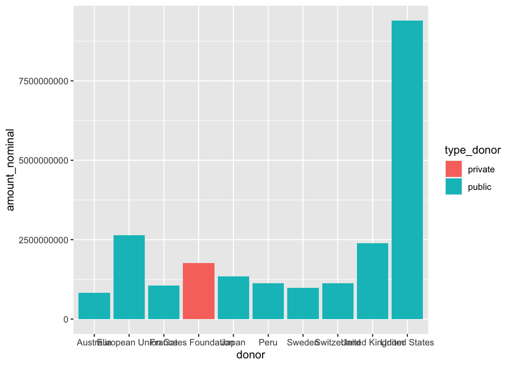

```r
q1 <- io_income_rs %>%
  drop_na(donor)%>%
  group_by(donor, type_donor)%>%
  summarize(amount_nominal = sum(amount_nominal, na.rm = TRUE)) %>%
  arrange(desc(amount_nominal))

q1<- q1[1:10,]

q1 %>%
  ggplot(mapping=aes(x=donor, y= amount_nominal, fill=type_donor))+
  geom_col() #minimal solution
```

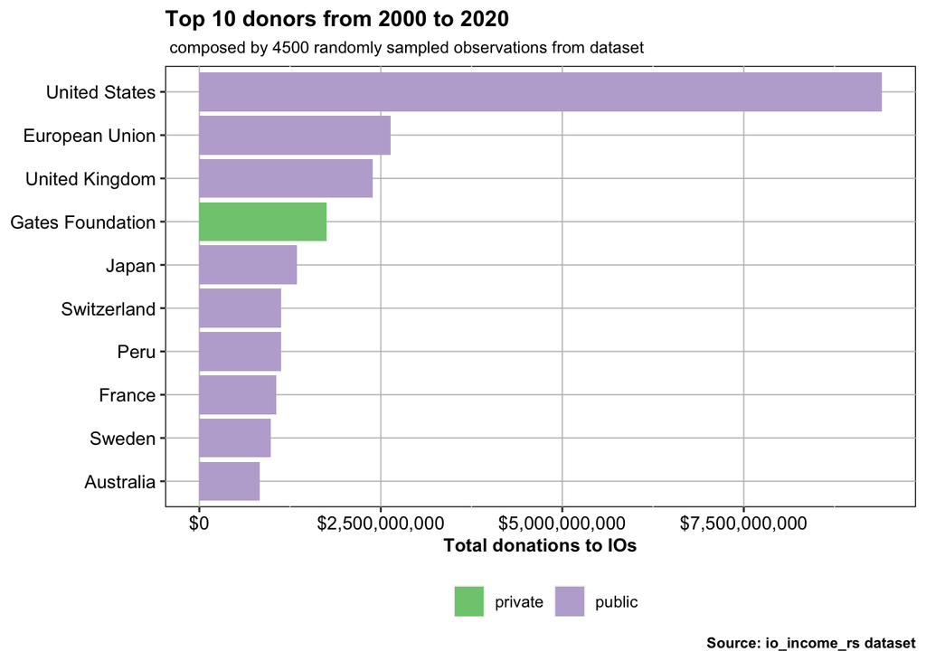

```r
q1 %>%
  ggplot(mapping=aes(x=reorder(donor, amount_nominal), y= amount_nominal, fill=type_donor))+
  geom_col()+
  scale_fill_brewer(type="qual", palette= "Accent", direction=1)+
  scale_y_continuous(labels=scales::dollar)+
  labs( x = NULL, y = "Total donations to IOs", title = "Top 10 donors from 2000 to 2020", #removing redundat info
    subtitle=" composed by 4500 randomly sampled observations from dataset",
    caption = "Source: io_income_rs dataset")+
  theme(panel.background = element_rect("white", "black", .5, "solid"),
    panel.grid.major = element_line(color = "grey", size = 0.3, linetype = "solid"),
    axis.text = element_text(color = "black", size = 10),
    title = element_text(color = "black", size = 10, face = "bold"),
    legend.title = element_blank(),
    plot.subtitle = element_text(color = "black", size = 9, face = "plain"),
    legend.position = "bottom") +
    coord_flip() #flipping it to simplify reading
```

## Question 2

Has the amount the US donates to all issue areas increased over time? Please illustrate this relationship in a line plot, colored by the respective issue areas.

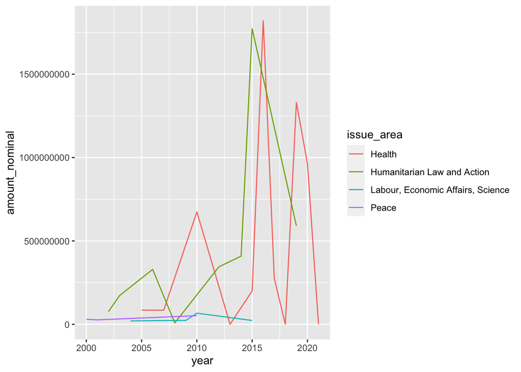

```r
io_income_rs %>%
  filter(donor== "United States") %>%
  group_by(year, issue_area)%>%
  summarize(amount_nominal = sum(amount_nominal, na.rm = TRUE)) %>%
  ggplot(mapping=aes(x=year, y=amount_nominal, color=issue_area))+
  geom_line() #minimal solution
```

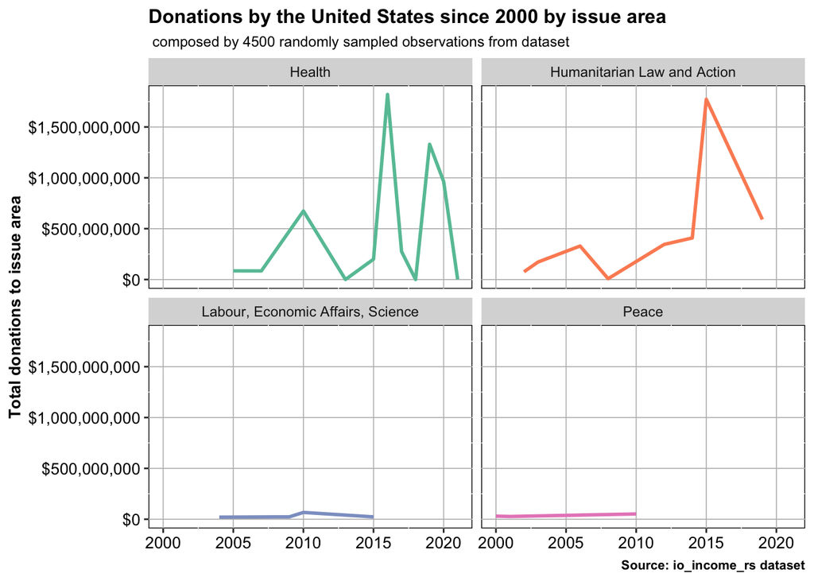

```r
io_income_rs %>%
  filter(donor== "United States") %>%
  group_by(year, issue_area)%>%
  summarize(amount_nominal = sum(amount_nominal, na.rm = TRUE)) %>%
  ggplot(mapping=aes(x=year, y=amount_nominal, color=issue_area))+
  geom_line(size=1)+
  scale_color_brewer(type="qual", palette= "Set2", direction=1)+
  scale_y_continuous(labels=scales::dollar)+
  labs( x = NULL, y = "Total donations to issue area", title = "Donations by the United States since 2000 by issue area", #removing redundat info
    subtitle=" composed by 4500 randomly sampled observations from dataset",
    caption = "Source: io_income_rs dataset")+
  theme(panel.background = element_rect("white", "black", .5, "solid"),
    panel.grid.major = element_line(color = "grey", size = 0.3, linetype = "solid"),
    axis.text = element_text(color = "black", size = 10),
    title = element_text(color = "black", size = 10, face = "bold"),
    legend.title = element_blank(),
    plot.subtitle = element_text(color = "black", size = 9, face = "plain"),
    legend.position = "none")+
    facet_wrap(~issue_area)
```

## Question 3

Plot the distribution of all donations in the year 2000 and in the year 2020 comparing public and private donors. Are there outliers for either of these types of donors in 2000? What about in 2020? (Tip: box plots are great for distributions, you might have to as.factor(year) and scale the amount_nominal in log10)

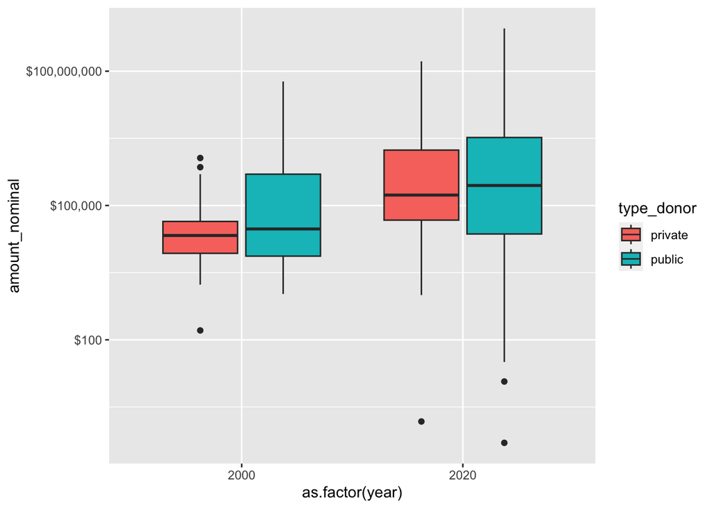

```r
io_income_rs %>%
  drop_na(type_donor) %>%
  filter(year==2000 | year == 2020) %>%
  ggplot(mapping=aes(x=as.factor(year), y=amount_nominal, fill=type_donor))+
  geom_boxplot()+
  scale_y_log10(labels=scales::dollar) #minimal solution
```

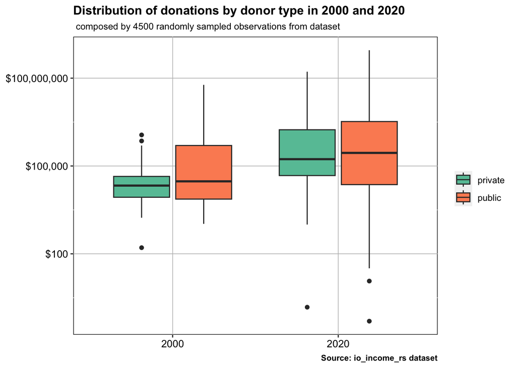

```r
io_income_rs %>%
  drop_na(type_donor) %>%
  filter(year==2000 | year == 2020) %>%
  ggplot(mapping=aes(x=as.factor(year), y=amount_nominal, fill=type_donor))+
  geom_boxplot()+
  scale_y_log10(labels=scales::dollar)+
  scale_fill_brewer(type="qual", palette= "Set2", direction=1)+
  labs( x = NULL, y = NULL, title = "Distribution of donations by donor type in 2000 and 2020", #removing redundat info
    subtitle=" composed by 4500 randomly sampled observations from dataset",
    caption = "Source: io_income_rs dataset")+
  theme(panel.background = element_rect("white", "black", .5, "solid"),
    panel.grid.major = element_line(color = "grey", size = 0.3, linetype = "solid"),
    axis.text = element_text(color = "black", size = 10),
    title = element_text(color = "black", size = 10, face = "bold"),
    legend.title = element_blank(),
    plot.subtitle = element_text(color = "black", size = 9, face = "plain"),
    legend.position = "right")
```

## Question 4

We want one scatter plot for each issue area containing all donation by year per donor type. The shape of the points should reflect the donor type. In each facet, we want a smoothed line to show the direction of the relationship (TIP: geom_smooth(method=“lm”)). This line should be colored “red”.

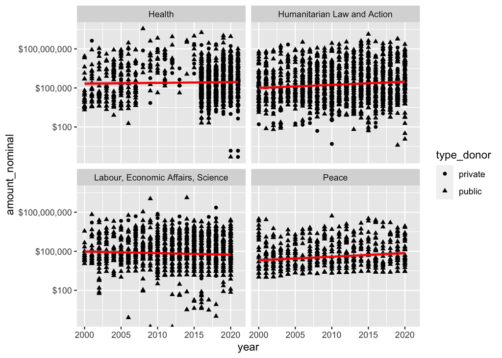

```r
io_income_rs %>%
  drop_na(type_donor)%>%
  ggplot(mapping=aes(x=year, y=amount_nominal))+
  geom_point(aes(shape=type_donor))+
  geom_smooth(method = "lm", color="red")+
  scale_y_log10(labels=scales::dollar)+
  facet_wrap(~issue_area) #minimal
```

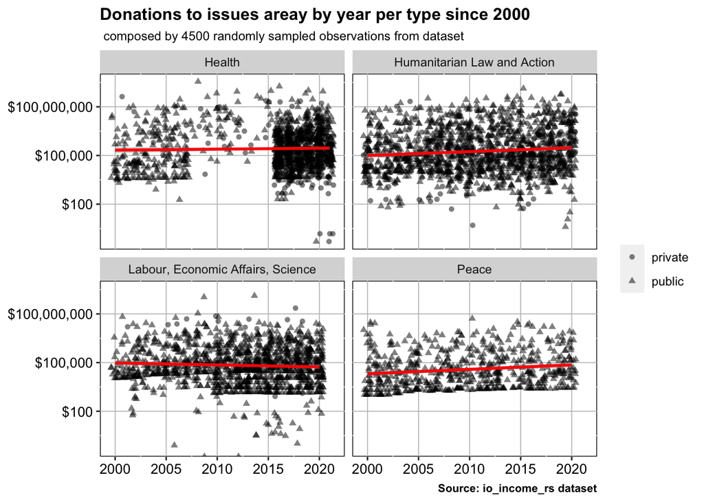

```r
io_income_rs %>%
  drop_na(type_donor)%>%
  ggplot(mapping=aes(x=year, y=amount_nominal))+
  geom_point(aes(shape=type_donor), position="jitter", alpha=.5)+ #position jitter adds random noise to each observation, so they do not line up by year.
  geom_smooth(method = "lm", color="red")+
  scale_y_log10(labels=scales::dollar)+
  facet_wrap(~issue_area)+
  labs( x = NULL, y = NULL, title = "Donations to issues areay by year per type since 2000", #removing redundat info
    subtitle=" composed by 4500 randomly sampled observations from dataset",
    caption = "Source: io_income_rs dataset")+
  theme(panel.background = element_rect("white", "black", .5, "solid"),
    panel.grid.major = element_line(color = "grey", size = 0.3, linetype = "solid"),
    axis.text = element_text(color = "black", size = 10),
    title = element_text(color = "black", size = 10, face = "bold"),
    legend.title = element_blank(),
    plot.subtitle = element_text(color = "black", size = 9, face = "plain"),
    legend.position = "right")
```